# Nonlinear Regression Models, Regression Trees and Rules-Based Models

Christian Thieme

7/3/2021

## Homework 5: Applied Predictive Modeling

#### 7.2

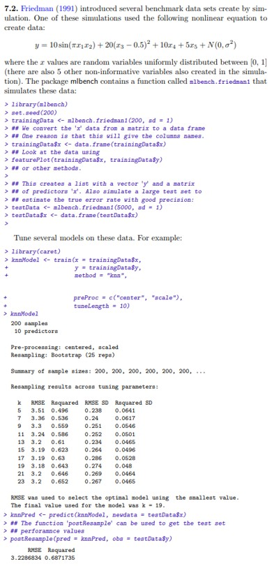

```r
set.seed(200)
trainingData <- mlbench.friedman1(200, sd = 1)
trainingData$x <- data.frame(trainingData$x)

testData <- mlbench.friedman1(5000, sd = 1)
testData$x <- data.frame(testData$x)

knn_fit<- train(x=trainingData$x,y=trainingData$y, method = "knn", preProcess = c("center", "scale"), tuneLength = 10)
knnPred <- predict(knn_fit, newdata = testData$x)
postResample(pred = knnPred, obs = testData$y)
```

```
##      RMSE  Rsquared       MAE
## 3.2040595 0.6819919 2.5683461
```

We now look at the variable importance of the knn fit.

```r
varImp((knn_fit))
```

```
## loess r-squared variable importance
##
##      Overall
## X4  100.0000
## X1   95.5047
## X2   89.6186
## X5   45.2170
## X3   29.9330
## X9    6.3299
## X10   5.5182
## X8    3.2527
## X6    0.8884
## X7    0.0000
```

It appears that variables X1-X10 are relevant to the KNN model with the exception of X7.

Let’s now look at a Multivariate Adaptive Regression Splines model (MARS):

```r
MARS_fit<- train(x = trainingData$x, y = trainingData$y, method = "earth",
  preProcess = c("center", "scale"), tuneLength = 10)
MARS_pred <- predict(MARS_fit, newdata = testData$x)
postResample(pred = MARS_pred, obs = testData$y)
```

```
##     RMSE Rsquared      MAE
## 1.776575 0.872700 1.358367
```

Having fit our model, lets see which variables are important to the fit.

```r
varImp(MARS_fit)
```

```
## earth variable importance
##
##    Overall
## X1  100.00
## X4   82.78
## X2   64.18
## X5   40.21
## X3   28.14
## X6    0.00
```

Looking at the output above, we can see that X1-X5 are relevant to the model which we know are the informative predictors.

#### 7.5

Exercise 6.3 describes data for a chemical manufacturing process. Use the same data imputation, data splitting, and pre-processing steps as before and train several nonlinear regression models.

We’ll use the same setup to test some non-linear methods:

```r
data("ChemicalManufacturingProcess")
ChemicalManufacturingProcess <- mice(data = ChemicalManufacturingProcess, m = 1, method = "pmm", seed = 123)
ChemicalManufacturingProcess <- mice::complete(ChemicalManufacturingProcess, 1)

set.seed(123)

train_test_split <- initial_split(ChemicalManufacturingProcess, prop = 0.80)

train <- training(train_test_split)

test <- testing(train_test_split)

features_train <- train[, -1]
y_train <- train[,1]

features_test <- test[, -1]
y_test <- test[,1]

ctrl <- trainControl(method = 'cv', number = 10)
```

**$(a)$ Which nonlinear regression model gives the optimal resampling and test set performance?**

- KNN

```r
knn <- train(features_train, y_train,
                 method="knn",
                 trControl = ctrl,
                 preProc = c('YeoJohnson', 'center', 'scale', 'pca'))
knn_predictions <- predict(knn, newdata=features_test)
knn
```

```
## k-Nearest Neighbors
##
## 141 samples
##  57 predictor
##
## Pre-processing: Yeo-Johnson transformation (27), centered (57), scaled
##  (57), principal component signal extraction (57)
## Resampling: Cross-Validated (10 fold)
## Summary of sample sizes: 127, 128, 125, 127, 128, 126, ...
## Resampling results across tuning parameters:
##
##   k  RMSE      Rsquared   MAE
##   5  1.341861  0.5098621  1.062598
##   7  1.358116  0.4881036  1.102625
##   9  1.392364  0.4661462  1.139923
##
## RMSE was used to select the optimal model using the smallest value.
## The final value used for the model was k = 5.
```

```r
postResample(pred=knn_predictions,y_test)
```

```
##      RMSE  Rsquared       MAE
## 1.1483501 0.6626058 0.9475111
```

- Neural Networks

```r
nnetGrid <- expand.grid(size=c(1:10),
                        decay = c(0,0.01,.1),
                      bag = FALSE )

nnetTune <- train(features_train, y_train,
                  method="avNNet",
                  tuneGrid = nnetGrid,
                 preProc = c('YeoJohnson', 'center', 'scale', 'pca'),
                 linout=T,
                 trace=F,
                 MaxNWts=10 * (ncol(features_train)+1) + 10 + 1, maxit=500)
nnetTune
```

```
## Model Averaged Neural Network
##
## 141 samples
##  57 predictor
##
## Pre-processing: Yeo-Johnson transformation (27), centered (57), scaled
##  (57), principal component signal extraction (57)
## Resampling: Bootstrapped (25 reps)
## Summary of sample sizes: 141, 141, 141, 141, 141, 141, ...
## Resampling results across tuning parameters:
##
##   size  decay  RMSE      Rsquared    MAE
##    1    0.00   1.660444  0.29444791  1.354168
##    1    0.01   1.426499  0.45250913  1.123151
##    1    0.10   1.412849  0.47226219  1.118842
##    2    0.00   1.507279  0.39345953  1.217148
##    2    0.01   1.373074  0.50104357  1.092403
##    2    0.10   1.481587  0.48387395  1.127596
##    3    0.00   2.092945  0.35557938  1.635466
##    3    0.01   1.840336  0.38190043  1.449070
##    3    0.10   1.857976  0.40021803  1.401618
##    4    0.00   2.412104  0.22485158  1.929662
##    4    0.01   1.921245  0.31338218  1.495299
##    4    0.10   1.895876  0.37571638  1.421616
##    5    0.00   2.485148  0.24419604  1.957258
##    5    0.01   1.704763  0.39801788  1.347274
##    5    0.10   2.056612  0.33983848  1.498018
##    6    0.00   3.219662  0.19909970  2.456685
##    6    0.01   1.720972  0.37885923  1.356747
##    6    0.10   2.054051  0.32070762  1.468125
##    7    0.00   4.379270  0.14936414  3.117547
##    7    0.01   1.610475  0.42579143  1.271070
##    7    0.10   2.052748  0.30909648  1.506220
##    8    0.00   6.088999  0.10498777  4.184413
##    8    0.01   1.710044  0.36218366  1.350626
##    8    0.10   1.944990  0.34529444  1.454777
##    9    0.00   7.787763  0.07223681  5.193777
##    9    0.01   1.797634  0.36624490  1.391814
##    9    0.10   1.918946  0.33460016  1.454235
##   10    0.00   9.873383  0.05443961  6.299442
##   10    0.01   1.989810  0.29937277  1.517033
##   10    0.10   1.867830  0.35178809  1.408637
##
## Tuning parameter 'bag' was held constant at a value of FALSE
## RMSE was used to select the optimal model using the smallest value.
## The final values used for the model were size = 2, decay = 0.01 and bag = FALSE.
```

```r
nn_predictions <- predict(nnetTune, newdata=features_test)
postResample(pred=nn_predictions,y_test)
```

```
##      RMSE  Rsquared       MAE
## 1.4363498 0.4176806 1.1572885
```

- Support Vector Machines

```r
svm <- train(features_train, y_train,
                 method="svmRadial",
                 trControl = ctrl,
                 preProc = c('YeoJohnson', 'center', 'scale', 'pca'))

svm
```

```
## Support Vector Machines with Radial Basis Function Kernel
##
## 141 samples
##  57 predictor
##
## Pre-processing: Yeo-Johnson transformation (27), centered (57), scaled
##  (57), principal component signal extraction (57)
## Resampling: Cross-Validated (10 fold)
## Summary of sample sizes: 127, 127, 128, 128, 128, 128, ...
## Resampling results across tuning parameters:
##
##   C     RMSE      Rsquared   MAE
##   0.25  1.501143  0.5174819  1.224633
##   0.50  1.372837  0.5376974  1.132132
##   1.00  1.246472  0.5926221  1.018897
##
## Tuning parameter 'sigma' was held constant at a value of 0.02775125
## RMSE was used to select the optimal model using the smallest value.
## The final values used for the model were sigma = 0.02775125 and C = 1.
```

```r
svm_predictions <- predict(svm, newdata=features_test)
postResample(pred=svm_predictions,y_test)
```

```
##     RMSE Rsquared      MAE
## 1.324893 0.507160 1.124479
```

[output not shown]

**$(b)$ Which predictors are most important in the optimal nonlinear regression model? Do either the biological or process variables dominate the list? How do the top ten important predictors compare to the top ten predictors from the optimal linear model?**

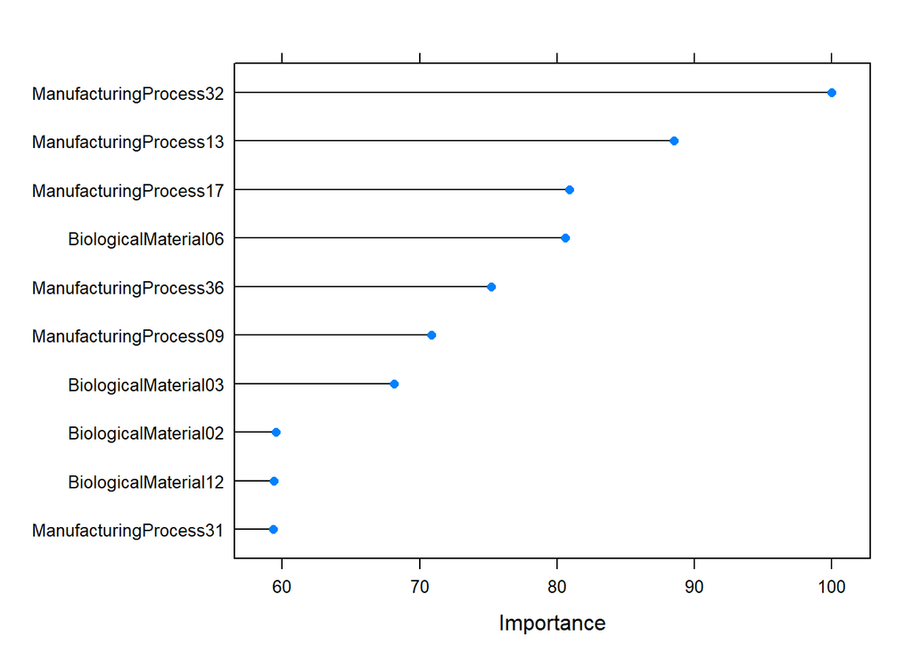

```r
svm_var_imp <- varImp(svm)
plot(svm_var_imp, top = 10)
```

Looking at the variable importance, we can see that the variable importance is split between the manufacturing and biological predictors. One does not outweight the other. They are both needed.

Our previous model from Ch.6 placed the following importance on the top features:

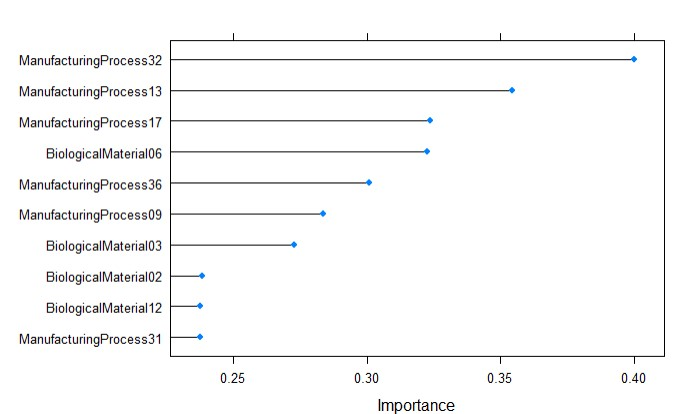

In looking at this, we can see that the importance is exactly the same as our previous run with the elastic net model.

**$(c)$ Explore the relationships between the top predictors and the response for the predictors that are unique to the optimal nonlinear regression model.Do these plots reveal intuition about the biological or process predictors and their relationship with yield?**

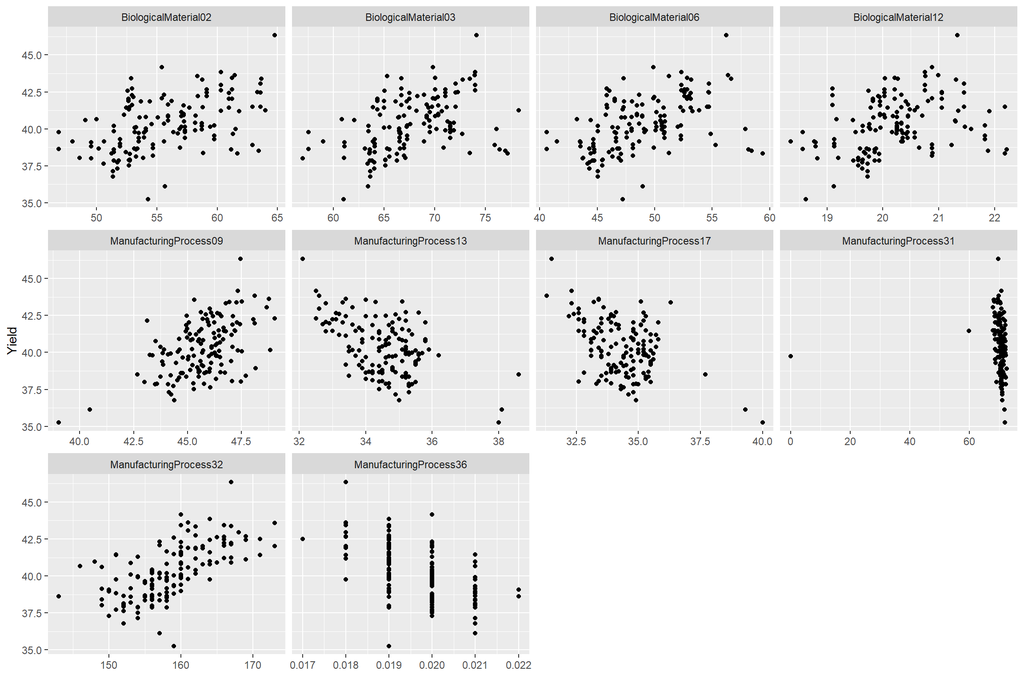

```r
svm_imp_df <- rownames(svm_var_imp$importance  %>%
                data.frame() %>%
                arrange(desc(Overall)) %>%
                top_n(10, wt = Overall))

var_top_10 <- train[,names(train) %in% c(svm_imp_df, 'Yield')]# %>%
 # bind_cols(Yield = ChemicalManufacturingProcess$Yield)


var_top_10 %>%
  gather(variable, value, -Yield) %>%
  ggplot(aes(x = value, y = Yield)) +
  geom_point() +
  facet_wrap(~variable, scales = 'free_x') +
  labs(x = element_blank())
```